# IODS course project

# Introduction to Open Data Science - Course Project

# About the project

This is a course work to practice the use of R and GitHub in sharing data and for research. This version is updated by a person that has never used R or Git so this should be amusing to watch. I’m alrwady overwhelmed and exhausted of this work but lets see how far will I get.

Link to my GitHub repository: https://github.com/Moonabeardanen/IODS-project

# Start me up!

## R for health data science book

### The exercise set 1

The first chapters were very introductory, but helpful. I will try out those functions soon.

# Simple regression and model validation

## Data characteristics

First we observe the data characteristics:

```r
The_data <- read.csv("data/Final_data.csv")
str(The_data)
```

```
## 'data.frame':    166 obs. of  8 variables:
##  $ X       : int  1 2 3 4 5 6 7 8 9 10 ...
##  $ gender  : chr  "F" "M" "F" "M" ...
##  $ age     : int  53 55 49 53 49 38 50 37 37 42 ...
##  $ attitude: num  3.7 3.1 2.5 3.5 3.7 3.8 3.5 2.9 3.8 2.1 ...
##  $ deep    : num  3.58 2.92 3.5 3.5 3.67 ...
##  $ stra    : num  3.38 2.75 3.62 3.12 3.62 ...
##  $ surf    : num  2.58 3.17 2.25 2.25 2.83 ...
##  $ points  : int  25 12 24 10 22 21 21 31 24 26 ...
```

```r
summary(The_data)
```

```
##        X             gender               age           attitude
##  Min.   :  1.00   Length:166         Min.   :17.00   Min.   :1.400
##  1st Qu.: 42.25   Class :character   1st Qu.:21.00   1st Qu.:2.600
##  Median : 83.50   Mode  :character   Median :22.00   Median :3.200
##  Mean   : 83.50                      Mean   :25.51   Mean   :3.143
##  3rd Qu.:124.75                      3rd Qu.:27.00   3rd Qu.:3.700
##  Max.   :166.00                      Max.   :55.00   Max.   :5.000
##       deep            stra            surf           points
##  Min.   :1.583   Min.   :1.250   Min.   :1.583   Min.   : 7.00
##  1st Qu.:3.333   1st Qu.:2.625   1st Qu.:2.417   1st Qu.:19.00
##  Median :3.667   Median :3.188   Median :2.833   Median :23.00
##  Mean   :3.680   Mean   :3.121   Mean   :2.787   Mean   :22.72
##  3rd Qu.:4.083   3rd Qu.:3.625   3rd Qu.:3.167   3rd Qu.:27.75
##  Max.   :4.917   Max.   :5.000   Max.   :4.333   Max.   :33.00
```

We have here 166 different observations with 7 variables. Gender and gender are demographical data from the participants of the test. Deep, stra and surf are numerical values which are derived through means of values of single questions. Attitude is scaled to fit the same Likert scale than deep, stra and surf questions. Points describes the number of points this individual received from the test. The participants are rather young.

Lets now investigate the characteristics of the data in form of plots:

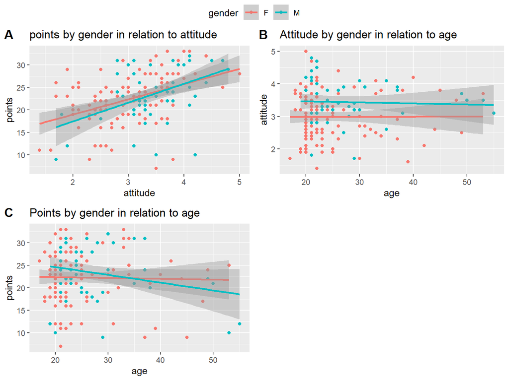

```r
library(ggplot2)

# plotted data
p1 <- ggplot(The_data, aes(x = attitude, y=points, col= gender))+
  geom_point()+
  geom_smooth(method = "lm")+
  ggtitle("points by gender in relation to attitude")

p2 <- ggplot(The_data, aes(x = age, y=attitude, col= gender))+
  geom_point()+
  geom_smooth(method = "lm")+
  ggtitle("Attitude by gender in relation to age")

p3 <- ggplot(The_data, aes(x = age, y = points, col = gender))+
  geom_point()+
  geom_smooth(method = "lm")+
  ggtitle("Points by gender in relation to age")

# Arrangements of the plots
ggpubr::ggarrange(
  plotlist = list(p1, p2, p3), labels = "AUTO",
  common.legend = T)
```

In the figure A you can see that in both male and female the points increase as the attitude rises. This effect however, is is stronger in males. In the figure B the attitude of males is slightly higher than in females in younger respondents. However, as we get closer to the 50 years of age, the number of observations decrease and the separation is not so clear anymore. Majority of the respondents are 20-35 years old. In the figure C you can see that the points of older men are clearly lower than younger men. This however is not observed with females.

## Regression model

Then the regression model of the data:

```r
library(GGally)
library(ggplot2)

my_model <- lm(points ~ attitude + deep + stra + surf, data = The_data)
summary(my_model)
```

```
##
## Call:
## lm(formula = points ~ attitude + deep + stra + surf, data = The_data)
##
## Residuals:
##      Min       1Q   Median       3Q      Max
## -16.7335  -3.1992   0.7975   3.4002  11.6582
##
## Coefficients:
##             Estimate Std. Error t value Pr(>|t|)
## (Intercept)  15.4000     5.0245   3.065  0.00255 **
## attitude      3.4362     0.5739   5.987 1.34e-08 ***
## deep         -1.0072     0.7870  -1.280  0.20247
## stra          0.8847     0.5411   1.635  0.10398
## surf         -0.9105     0.8390  -1.085  0.27948
## ---
## Signif. codes:  0 '***' 0.001 '**' 0.01 '*' 0.05 '.' 0.1 ' ' 1
##
## Residual standard error: 5.286 on 161 degrees of freedom
## Multiple R-squared:  0.2154, Adjusted R-squared:  0.1959
## F-statistic: 11.05 on 4 and 161 DF,  p-value: 6.057e-08
```

Let’s observe this test data with figures. However, to make this more clear let’s make a new model where the deep, stra and surf variables are removed since the attitude data was the only significant variable in the model.

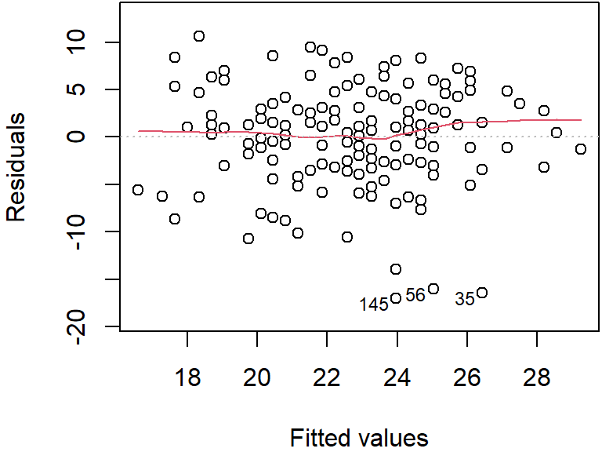

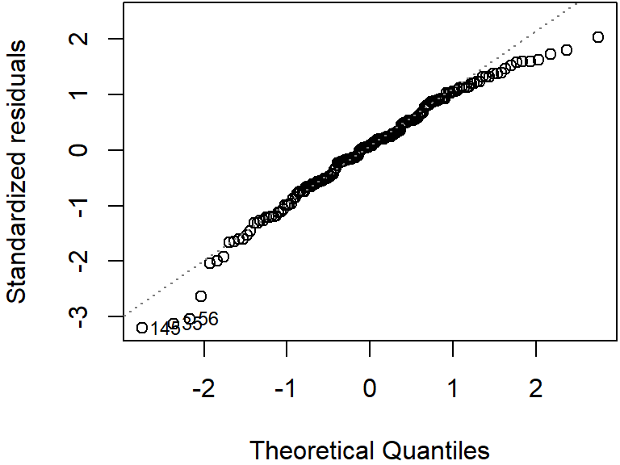

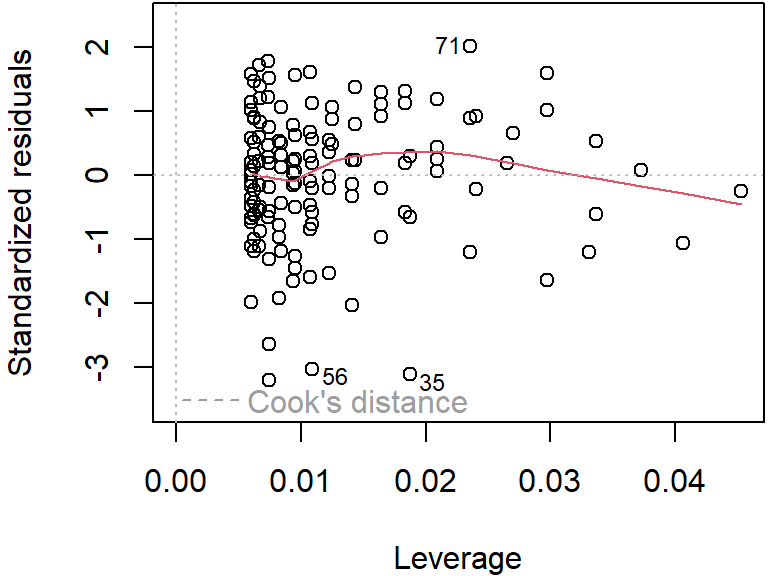

```r
# simpler model
my_model1 <- lm(points ~ attitude, data = The_data)

#the residuals vs. fitted values, normal QQ, and residuals vs leverage plots
par(mar = c(4, 4, .1, .1))
plot(my_model1, which = c(1,2,5))
```

The linear model assumes linearity and a normally distributed residual. The model seems to meet the normality assumption, evident from the QQ-plot. Additionally, there’s consistent variance in errors, shown in the residual plot, and no points significantly impacting the model. In conclusion, the model effectively describes the relationship between the points and attitude.

That’s all folks!

# Logistic regression

## data observations

For this weeks work, lets observe the data provided for us regarding student alcohol consumption.

```r
alc <- read.csv("alc.csv")

library(dplyr)
glimpse(alc)
```

```
## Rows: 370
## Columns: 39
## $ X.2        <int> 1, 2, 3, 4, 5, 6, 7, 8, 9, 10, 11, 12, 13, 14, 15, 16, 17, …
## $ X.1        <int> 1, 2, 3, 4, 5, 6, 7, 8, 9, 10, 11, 12, 13, 14, 15, 16, 17, …
## $ X          <int> 1, 2, 3, 4, 5, 6, 7, 8, 9, 10, 11, 12, 13, 14, 15, 16, 17, …
## $ school     <chr> "GP", "GP", "GP", "GP", "GP", "GP", "GP", "GP", "GP", "GP",…
## $ sex        <chr> "F", "F", "F", "F", "F", "M", "M", "F", "M", "M", "F", "F",…
## $ age        <int> 18, 17, 15, 15, 16, 16, 16, 17, 15, 15, 15, 15, 15, 15, 15,…
## $ address    <chr> "U", "U", "U", "U", "U", "U", "U", "U", "U", "U", "U", "U",…
## $ famsize    <chr> "GT3", "GT3", "LE3", "GT3", "GT3", "LE3", "LE3", "GT3", "LE…
## $ Pstatus    <chr> "A", "T", "T", "T", "T", "T", "T", "A", "A", "T", "T", "T",…
## $ Medu       <int> 4, 1, 1, 4, 3, 4, 2, 4, 3, 3, 4, 2, 4, 4, 2, 4, 4, 3, 3, 4,…
## $ Fedu       <int> 4, 1, 1, 2, 3, 3, 2, 4, 2, 4, 4, 1, 4, 3, 2, 4, 4, 3, 2, 3,…
## $ Mjob       <chr> "at_home", "at_home", "at_home", "health", "other", "servic…
## $ Fjob       <chr> "teacher", "other", "other", "services", "other", "other", …
```

[output cut: 26 more lines]

Lets then perform some hypotheses of the correlation of alcohol use to other characteristics:

Students that goes out with friends a lot have higher alcohol consumption (variable “goout” numeric: from 1 - very low to 5 -very high) Students that have good quality family relationships have lower alcohol consumption (variable “famrel” numeric: from 1 - very bad to 5 - excellent) Students that have larger study time consumes less alcohol (variable “studytime” numeric: 1 - <2 hours, 2 - 2 to 5 hours, 3 - 5 to 10 hours, or 4 - >10 hours) Students that have better health status have lower alcohol comsumption (variable “health” numeric: from 1 - very bad to 5 - very good)

Let’s observe these correlations with a tabulation and plots:

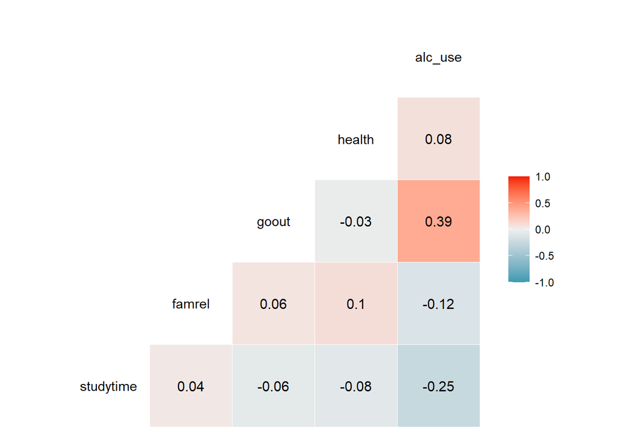

```r
library(ggplot2)
library(ggpubr)

# correlation tabulation from all the hypotheses

corr <- ggcorr(alc[colnames(alc) %in% c("goout", "famrel", "studytime", "health", "alc_use")],
       palette = "RdBu", label = TRUE, label_round=2)
corr
```

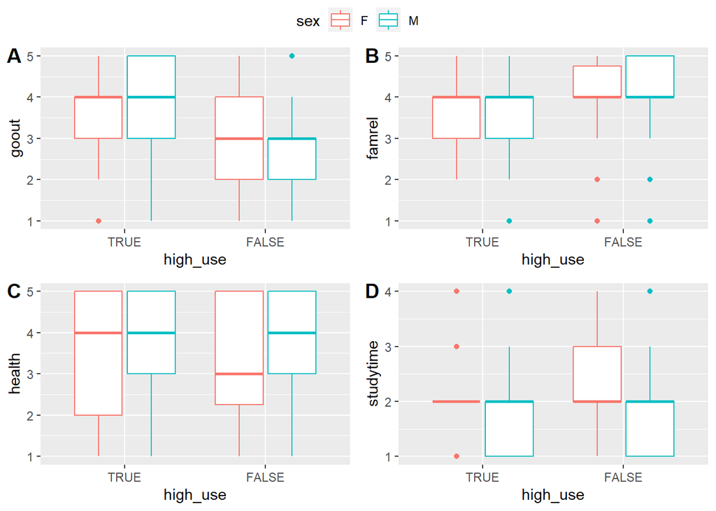

```r
# correlation with high consumption of alcohol with box plots

alc$high_use <- factor(alc$high_use, levels = c(TRUE, FALSE))

df <- data.frame("high_use", "activities")


g1 <- ggplot(alc, aes(x = high_use, y = goout, col = sex)) +
  geom_boxplot()
g2 <- ggplot(alc, aes(x = high_use, y = famrel, col = sex)) +
  geom_boxplot()
g3 <- ggplot(alc, aes(x = high_use, y = health, col = sex)) +
  geom_boxplot()
g4 <- ggplot(alc, aes(x = high_use, y = studytime, col = sex)) +
  geom_boxplot()

  ggpubr::ggarrange(
  plotlist = list(g1,g2,g3,g4), labels = "AUTO",
  common.legend = T)
```

From the box plots it seems that the boys and girls who go out with friends have higher alcohol use. Surprisingly, health status does not seem to be related with high alcohol use. Going out more and poor family relationships both seem to be associated with high alcohol consumption more than not. The study time does not seem to be associates with high alcohol consumption.

## logistic regression

Let’s then explore the relationships between the variables with logistic regression:

```r
# find the model with glm()
m <- glm(high_use ~ goout + famrel + health + studytime, data = alc, family = "binomial")

summary(m)
```

```
##
## Call:
## glm(formula = high_use ~ goout + famrel + health + studytime,
##     family = "binomial", data = alc)
##
## Coefficients:
##             Estimate Std. Error z value Pr(>|z|)
## (Intercept)  1.30262    0.76114   1.711 0.087008 .
## goout       -0.79566    0.12145  -6.551  5.7e-11 ***
## famrel       0.41533    0.14000   2.967 0.003010 **
## health      -0.17248    0.09276  -1.859 0.062969 .
## studytime    0.59448    0.16701   3.560 0.000372 ***
## ---
## Signif. codes:  0 '***' 0.001 '**' 0.01 '*' 0.05 '.' 0.1 ' ' 1
##
## (Dispersion parameter for binomial family taken to be 1)
##
##     Null deviance: 452.04  on 369  degrees of freedom
## Residual deviance: 376.19  on 365  degrees of freedom
## AIC: 386.19
##
## Number of Fisher Scoring iterations: 4
```

```r
# compute odds ratios (OR)
OR <- coef(m) %>% exp

# compute confidence intervals (CI)

CI <- confint(m) %>%exp

cbind(OR, CI)
```

```
##                    OR     2.5 %     97.5 %
## (Intercept) 3.6789255 0.8379073 16.7381578
## goout       0.4512833 0.3529115  0.5687263
## famrel      1.5148715 1.1531042  2.0005971
## health      0.8415759 0.6993355  1.0069611
## studytime   1.8120870 1.3178578  2.5415270
```

Odds ratios essentially indicate the predictive strength of explanatory variables. A value greater than 1 suggests that the variable is indicative of lower usage, while a value smaller than 1 suggests an association with high usage. In the case of health the OR is in both sides if 1 withing its confidence intervals, which means that its a poor predictor for alcohol use. On the other hand, going out is a good predictor of high usage and studytime and family relationships are both over 1 which means its a good indicator of low usage.

## predictive power

Lets observe how good this model is to predict low/high alcohol consumption:

```r
library(dplyr)

#prediction and observing the data
prob <- predict(m, type = "response")
alc <- mutate(alc, probability = prob)
alc <- mutate(alc, prediction = probability > 0.5)
select(alc, famrel, goout, studytime, high_use, probability, prediction) %>% tail(30)
```

```
##     famrel goout studytime high_use probability prediction
## 341      3     2         1    FALSE   0.7377554       TRUE
## 342      5     2         3    FALSE   0.9469231       TRUE
## 343      4     2         2    FALSE   0.8853546       TRUE
## 344      2     4         2    FALSE   0.4917811      FALSE
## 345      3     2         2    FALSE   0.8360071       TRUE
## 346      3     4         2     TRUE   0.5093724       TRUE
## 347      4     2         3    FALSE   0.9083511       TRUE
## 348      5     1         1    FALSE   0.9528271       TRUE
## 349      5     3         1    FALSE   0.7103031       TRUE
## 350      3     2         2     TRUE   0.7831054       TRUE
## 351      4     3         1     TRUE   0.6579125       TRUE
## 352      3     3         3    FALSE   0.8065322       TRUE
## 353      3     5         1    FALSE   0.2674327      FALSE
## 354      5     4         3    FALSE   0.8590707       TRUE
```

[output cut: 16 more lines]

```r
# how well the predictions were true

table(high_use = alc$high_use, prediction = alc$prediction)
```

```
##         prediction
## high_use FALSE TRUE
##    TRUE     43   68
##    FALSE    27  232
```

```r
table(high_use = alc$high_use, prediction = alc$prediction) %>% prop.table %>% addmargins
```

```
##         prediction
## high_use      FALSE       TRUE        Sum
##    TRUE  0.11621622 0.18378378 0.30000000
##    FALSE 0.07297297 0.62702703 0.70000000
##    Sum   0.18918919 0.81081081 1.00000000
```

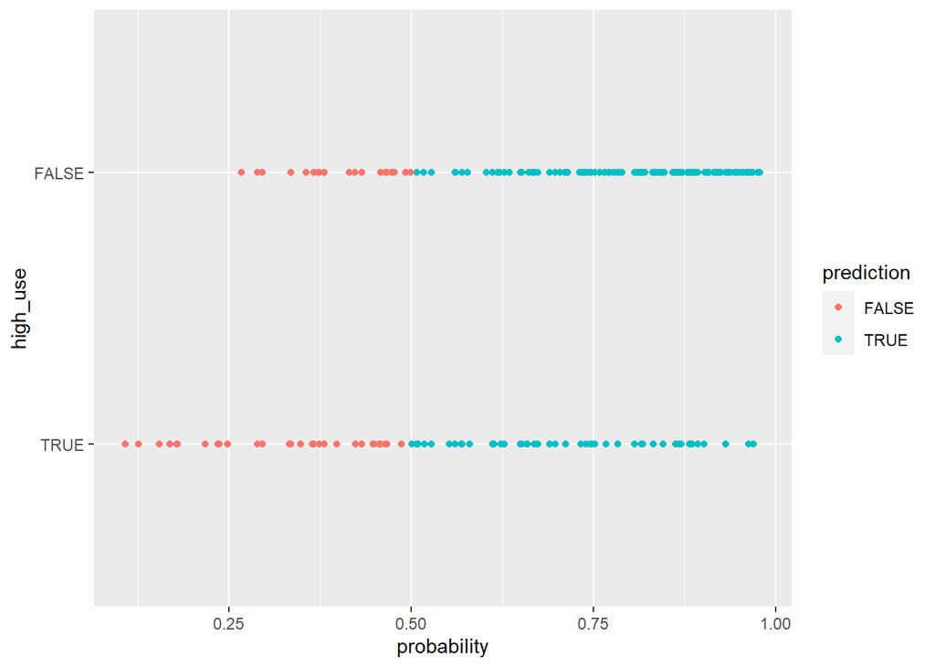

```r
# plotting the tale

g <- ggplot(alc, aes(x = probability, y = high_use, col = prediction))

g + geom_point()
```

```r
library(boot)
loss_func <- function(class, prob) {
  n_wrong <- abs(class - prob) > 0.5
  mean(n_wrong)
}
# average of wrong predictions in the data

cv <- cv.glm(data = alc, cost = loss_func, glmfit = m, K = nrow(alc))

cv$delta[1]
```

```
## [1] 0.2621622
```

Average of wrong predictions with these variables is 0.262… or 26 %.

we will continue next week again!

# Clustering and classification

This week we are practicing with a Boston data from the MASS package. First lets load the data and observe the structure and dimensions of it:

```r
# accessing the data

library(MASS)
library(corrplot)
library(tidyr)
data("boston")

# structure and dimensions
str(Boston)
```

```
## 'data.frame':    506 obs. of  14 variables:
##  $ crim   : num  0.00632 0.02731 0.02729 0.03237 0.06905 ...
##  $ zn     : num  18 0 0 0 0 0 12.5 12.5 12.5 12.5 ...
##  $ indus  : num  2.31 7.07 7.07 2.18 2.18 2.18 7.87 7.87 7.87 7.87 ...
##  $ chas   : int  0 0 0 0 0 0 0 0 0 0 ...
##  $ nox    : num  0.538 0.469 0.469 0.458 0.458 0.458 0.524 0.524 0.524 0.524 ...
##  $ rm     : num  6.58 6.42 7.18 7 7.15 ...
##  $ age    : num  65.2 78.9 61.1 45.8 54.2 58.7 66.6 96.1 100 85.9 ...
##  $ dis    : num  4.09 4.97 4.97 6.06 6.06 ...
##  $ rad    : int  1 2 2 3 3 3 5 5 5 5 ...
##  $ tax    : num  296 242 242 222 222 222 311 311 311 311 ...
##  $ ptratio: num  15.3 17.8 17.8 18.7 18.7 18.7 15.2 15.2 15.2 15.2 ...
##  $ black  : num  397 397 393 395 397 ...
##  $ lstat  : num  4.98 9.14 4.03 2.94 5.33 ...
##  $ medv   : num  24 21.6 34.7 33.4 36.2 28.7 22.9 27.1 16.5 18.9 ...
```

```r
dim(Boston)
```

```
## [1] 506  14
```

The data describes housing values in suburbs of boston and it has 506 observations and 14 variables. The meanings of each individual variable can be found through this link: https://stat.ethz.ch/R-manual/R-devel/library/MASS/html/Boston.html.

Next lets observe the graphical overview of the data:

```r
summary(Boston)
```

```
##       crim                zn             indus            chas
##  Min.   : 0.00632   Min.   :  0.00   Min.   : 0.46   Min.   :0.00000
##  1st Qu.: 0.08205   1st Qu.:  0.00   1st Qu.: 5.19   1st Qu.:0.00000
##  Median : 0.25651   Median :  0.00   Median : 9.69   Median :0.00000
##  Mean   : 3.61352   Mean   : 11.36   Mean   :11.14   Mean   :0.06917
##  3rd Qu.: 3.67708   3rd Qu.: 12.50   3rd Qu.:18.10   3rd Qu.:0.00000
##  Max.   :88.97620   Max.   :100.00   Max.   :27.74   Max.   :1.00000
##       nox               rm             age              dis
##  Min.   :0.3850   Min.   :3.561   Min.   :  2.90   Min.   : 1.130
##  1st Qu.:0.4490   1st Qu.:5.886   1st Qu.: 45.02   1st Qu.: 2.100
##  Median :0.5380   Median :6.208   Median : 77.50   Median : 3.207
##  Mean   :0.5547   Mean   :6.285   Mean   : 68.57   Mean   : 3.795
##  3rd Qu.:0.6240   3rd Qu.:6.623   3rd Qu.: 94.08   3rd Qu.: 5.188
##  Max.   :0.8710   Max.   :8.780   Max.   :100.00   Max.   :12.127
##       rad              tax           ptratio          black
##  Min.   : 1.000   Min.   :187.0   Min.   :12.60   Min.   :  0.32
##  1st Qu.: 4.000   1st Qu.:279.0   1st Qu.:17.40   1st Qu.:375.38
##  Median : 5.000   Median :330.0   Median :19.05   Median :391.44
##  Mean   : 9.549   Mean   :408.2   Mean   :18.46   Mean   :356.67
##  3rd Qu.:24.000   3rd Qu.:666.0   3rd Qu.:20.20   3rd Qu.:396.23
##  Max.   :24.000   Max.   :711.0   Max.   :22.00   Max.   :396.90
##      lstat            medv
##  Min.   : 1.73   Min.   : 5.00
##  1st Qu.: 6.95   1st Qu.:17.02
##  Median :11.36   Median :21.20
##  Mean   :12.65   Mean   :22.53
##  3rd Qu.:16.95   3rd Qu.:25.00
##  Max.   :37.97   Max.   :50.00
```

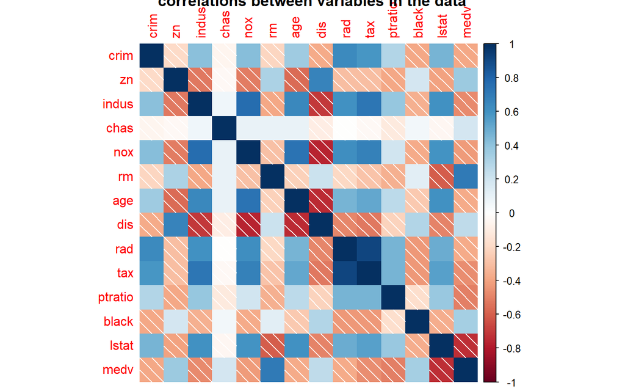

```r
cor_matrix <- cor(Boston) %>% round(digits = 2)

corrplot(cor_matrix, method="shade", title = "correlations between variables in the data")
```

For further investigations of the data, lets scale the dataset:

```r
boston_scaled <- scale(Boston)

# summaries of the scaled variables

summary(boston_scaled)
```

```
##       crim                 zn               indus              chas
##  Min.   :-0.419367   Min.   :-0.48724   Min.   :-1.5563   Min.   :-0.2723
##  1st Qu.:-0.410563   1st Qu.:-0.48724   1st Qu.:-0.8668   1st Qu.:-0.2723
##  Median :-0.390280   Median :-0.48724   Median :-0.2109   Median :-0.2723
##  Mean   : 0.000000   Mean   : 0.00000   Mean   : 0.0000   Mean   : 0.0000
##  3rd Qu.: 0.007389   3rd Qu.: 0.04872   3rd Qu.: 1.0150   3rd Qu.:-0.2723
##  Max.   : 9.924110   Max.   : 3.80047   Max.   : 2.4202   Max.   : 3.6648
##       nox                rm               age               dis
##  Min.   :-1.4644   Min.   :-3.8764   Min.   :-2.3331   Min.   :-1.2658
##  1st Qu.:-0.9121   1st Qu.:-0.5681   1st Qu.:-0.8366   1st Qu.:-0.8049
##  Median :-0.1441   Median :-0.1084   Median : 0.3171   Median :-0.2790
##  Mean   : 0.0000   Mean   : 0.0000   Mean   : 0.0000   Mean   : 0.0000
##  3rd Qu.: 0.5981   3rd Qu.: 0.4823   3rd Qu.: 0.9059   3rd Qu.: 0.6617
##  Max.   : 2.7296   Max.   : 3.5515   Max.   : 1.1164   Max.   : 3.9566
##       rad               tax             ptratio            black
##  Min.   :-0.9819   Min.   :-1.3127   Min.   :-2.7047   Min.   :-3.9033
##  1st Qu.:-0.6373   1st Qu.:-0.7668   1st Qu.:-0.4876   1st Qu.: 0.2049
##  Median :-0.5225   Median :-0.4642   Median : 0.2746   Median : 0.3808
##  Mean   : 0.0000   Mean   : 0.0000   Mean   : 0.0000   Mean   : 0.0000
##  3rd Qu.: 1.6596   3rd Qu.: 1.5294   3rd Qu.: 0.8058   3rd Qu.: 0.4332
##  Max.   : 1.6596   Max.   : 1.7964   Max.   : 1.6372   Max.   : 0.4406
##      lstat              medv
##  Min.   :-1.5296   Min.   :-1.9063
##  1st Qu.:-0.7986   1st Qu.:-0.5989
##  Median :-0.1811   Median :-0.1449
##  Mean   : 0.0000   Mean   : 0.0000
##  3rd Qu.: 0.6024   3rd Qu.: 0.2683
##  Max.   : 3.5453   Max.   : 2.9865
```

```r
# class of the boston_scaled object
class(boston_scaled)
```

```
## [1] "matrix" "array"
```

```r
boston_scaled <- as.data.frame(boston_scaled)
```

Let’s make a new variable of the crime rate of Boston:

```r
# new categorical crime varibale
bins <- quantile(boston_scaled$crim)
bins
```

```
##           0%          25%          50%          75%         100%
## -0.419366929 -0.410563278 -0.390280295  0.007389247  9.924109610
```

```r
crime <- cut(boston_scaled$crim, breaks = bins, include.lowest = TRUE, labels = c("low","med_low","med_high","high"))

# remove original crim from the dataset
boston_scaled <- dplyr::select(boston_scaled, -crim)

# add the new categorical value to scaled data
boston_scaled <- data.frame(boston_scaled, crime)
```

Now lets divide the dataset to train and test sets:

```r
n <- nrow(boston_scaled)

# choose randomly 80% of the rows
ind <- sample(n,  size = n * 0.8)

# create train and test set
train <- boston_scaled[ind,]
test <- boston_scaled[-ind,]
```

Then lets execute an linear discriminant analysis of the train set as the crime rate as the target variable:

```r
lda.fit <- lda(crime ~ ., data = train)
lda.fit
```

```
## Call:
## lda(crime ~ ., data = train)
##
## Prior probabilities of groups:
##       low   med_low  med_high      high
## 0.2475248 0.2376238 0.2599010 0.2549505
##
## Group means:
##                   zn      indus        chas        nox         rm        age
## low       1.01817607 -0.9391031 -0.11484506 -0.8800233  0.5109121 -0.9065696
## med_low  -0.04596299 -0.2799005 -0.02626030 -0.5826749 -0.1144812 -0.3691278
## med_high -0.37126774  0.1097795  0.17762524  0.2942363  0.2007784  0.4262831
## high     -0.48724019  1.0170891 -0.04298342  1.0834499 -0.4117524  0.7958332
##                 dis        rad        tax    ptratio      black       lstat
## low       0.8611149 -0.6890121 -0.7588071 -0.4616900  0.3757382 -0.79860161
## med_low   0.3802414 -0.5523924 -0.4728043 -0.1108151  0.3133223 -0.17134484
## med_high -0.3400449 -0.4065439 -0.3328870 -0.2548443  0.1335293 -0.06548532
## high     -0.8432854  1.6384176  1.5142626  0.7811136 -0.7368023  0.85095788
##                 medv
## low       0.57781163
## med_low   0.01851873
## med_high  0.21482470
## high     -0.69405453
##
## Coefficients of linear discriminants:
##                  LD1          LD2         LD3
## zn       0.096583206  0.742124376 -0.89371431
## indus   -0.002712898 -0.281151676  0.39669246
## chas    -0.114387329 -0.041344825  0.07533411
## nox      0.446248553 -0.611822760 -1.41909775
## rm      -0.122075706 -0.104922705 -0.25032751
## age      0.283414868 -0.479640853 -0.24289227
## dis     -0.043680690 -0.322065685  0.17379459
## rad      3.167226387  0.886638876 -0.03596491
## tax      0.037466552 -0.003981397  0.58724744
## ptratio  0.078724905  0.090548119 -0.38248614
## black   -0.121715304  0.023547297  0.11186813
## lstat    0.185291615 -0.120353057  0.42824733
## medv     0.164786982 -0.317037863 -0.12746584
##
## Proportion of trace:
##    LD1    LD2    LD3
## 0.9502 0.0366 0.0132
```

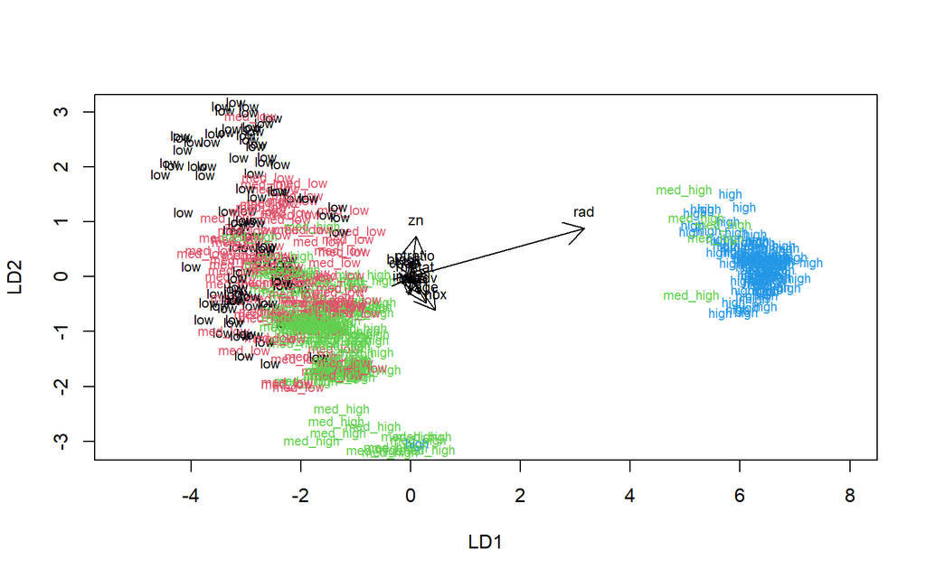

```r
# plotting the analysis

lda.arrows <- function(x, myscale = 1, arrow_heads = 0.2, color = "black", tex = 0.75, choices = c(1,2)){
  heads <- coef(x)
  graphics::arrows(x0 = 0, y0 = 0,
         x1 = myscale * heads[,choices[1]],
         y1 = myscale * heads[,choices[2]], col=color, length = arrow_heads)
  text(myscale * heads[,choices], labels = row.names(heads),
       cex = tex, col=color, pos=3)}

classes <- as.numeric(train$crime)

plot(lda.fit, dimen = 2, col = classes)
lda.arrows(lda.fit, myscale = 1)
```

IT seems that the variable rad, i.e, index of accessibility to radial highways, have significance in this model with some classes.

Let’s observe this more closely by predicting the classes with the LDA and cross tabulate the results:

```r
# saving the correct classes from test data
correct_classes <- test$crime

# removing the crime variable from test data
test <- dplyr::select(test, -crime)

# predictions
lda.pred <- predict(lda.fit, newdata = test)
table(correct = correct_classes, predicted = lda.pred$class)
```

```
##           predicted
## correct    low med_low med_high high
##   low       14      10        3    0
##   med_low    2      18       10    0
##   med_high   0       6       14    1
##   high       0       0        0   24
```

Lets take the the Boston dataset again and calculate the usual distances between vectors (fist_euc) and the absolute distances between vectors (dist_man):

```r
# reloading the dataset
data("Boston")

# standardizing the dataset
scaled_boston <- scale(Boston)
scaled_data <- as.data.frame(scaled_boston)

dist_eu <- dist(scaled_data ,method = "euclidean")
summary(dist_eu)
```

```
##    Min. 1st Qu.  Median    Mean 3rd Qu.    Max.
##  0.1343  3.4625  4.8241  4.9111  6.1863 14.3970
```

```r
dist_man <- dist(scaled_data, method = "manhattan")
summary(dist_man)
```

```
##    Min. 1st Qu.  Median    Mean 3rd Qu.    Max.
##  0.2662  8.4832 12.6090 13.5488 17.7568 48.8618
```

Let’s then check the k-means of the Boston dataset:

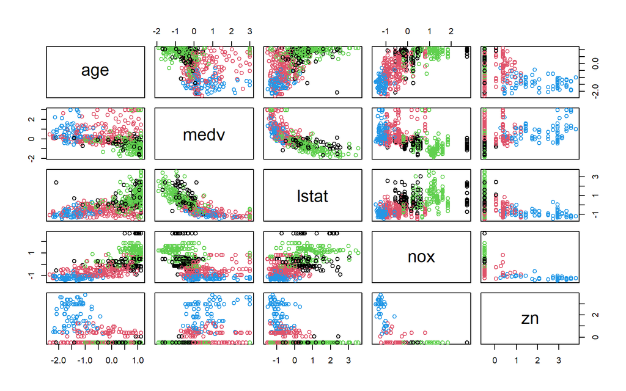

```r
# running the k-means analysis
km <- kmeans(scaled_data, centers = 4)

## The pairs are reduced so the data is observable
pairs(scaled_data[c("age", "medv", "lstat", "nox", "zn")], col = km$cluster)
```

Lets then investigate what the optimal number of clusters would be:

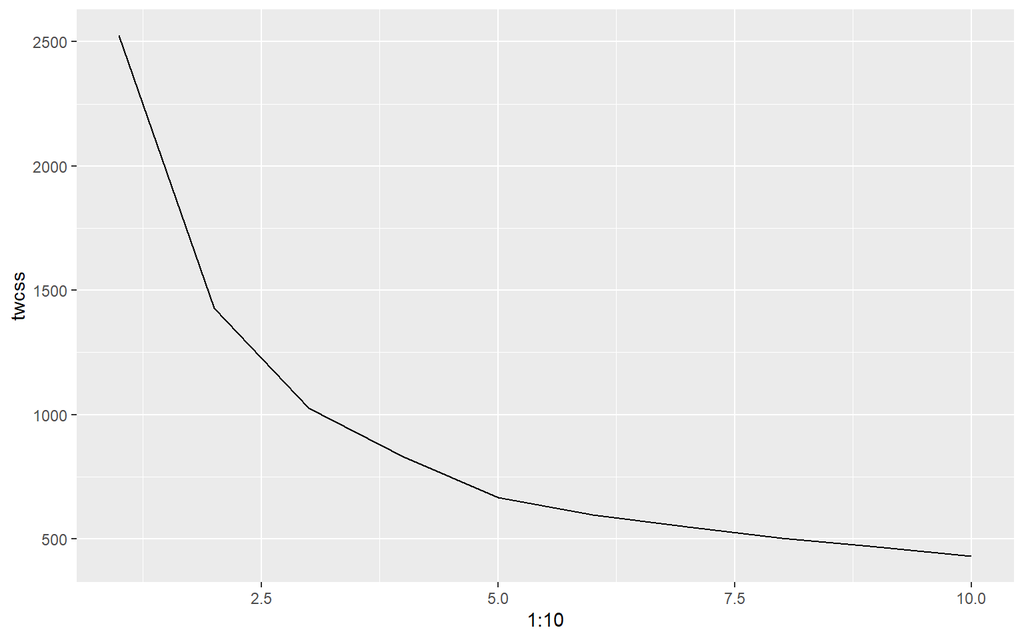

```r
library(ggplot2)
set.seed(123)

# determine the number of clusters
k_max <- 10

# calculate the total within sum of squares
twcss <- sapply(1:k_max, function(k){kmeans(scaled_data[c("age", "medv", "lstat", "nox", "zn")], k)$tot.withinss})

# visualize the results
qplot(x = 1:10, y = twcss, geom = 'line')
```

Let’s therefore change the k-means clusters to two:

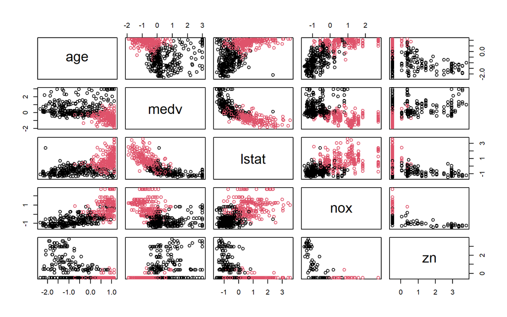

```r
# k-means clustering
km <- kmeans(scaled_data[c("age", "medv", "lstat", "nox", "zn")], centers = 2)

# plot the Boston dataset with clusters
pairs(scaled_data[c("age", "medv", "lstat", "nox", "zn")], col = km$cluster)
```

## Bonus exercise code

```r
# reloading the dataset
library(MASS)
data("Boston")

# standardizing the dataset
scaled_boston <- scale(Boston)
scaled_data <- as.data.frame(scaled_boston)

# k-means with 3 clusters

km <- kmeans(scaled_data, centers = 3)

# new data with clusters assigned

data_with_clusters <- cbind(scaled_data, cluster = km$cluster)

# removing the chas variable as it is constant between the groups and interfering with the analysis

data_with_clusters <- dplyr::select(data_with_clusters, -chas)

# LDA with clusters as target classes

lda.bonus <- lda(cluster ~ ., data = data_with_clusters)
lda.bonus
```

```
## Call:
## lda(cluster ~ ., data = data_with_clusters)
##
## Prior probabilities of groups:
##          1          2          3
## 0.06916996 0.61067194 0.32015810
##
## Group means:
##         crim         zn      indus        nox         rm        age        dis
## 1 -0.2048299 -0.1564737  0.2306535  0.3342374  0.3344149  0.3170678 -0.3634565
## 2 -0.3882449  0.2731699 -0.6264383 -0.5823006  0.2188304 -0.4585819  0.4807157
## 3  0.7847946 -0.4872402  1.1450405  1.0384727 -0.4896488  0.8062002 -0.8383961
##           rad        tax    ptratio      black      lstat       medv
## 1 -0.02700292 -0.1304164 -0.4453253  0.1787986 -0.1976385  0.6422884
## 2 -0.58641200 -0.6161585 -0.2814183  0.3151747 -0.4640135  0.3182241
## 3  1.12436056  1.2034416  0.6329916 -0.6397959  0.9277624 -0.7457491
##
## Coefficients of linear discriminants:
##                 LD1         LD2
## crim     0.02479166 -0.13204141
## zn       0.42787622 -0.04638198
## indus    1.15646011  0.64348753
## nox      0.47943272  0.42987408
## rm       0.13637610 -0.12823804
## age     -0.06654278  0.30029385
## dis     -0.01915297  0.20848367
## rad      0.74637979  0.69845574
## tax      0.27967651 -1.02040695
## ptratio  0.19355485 -0.21964359
## black   -0.04753224  0.11581547
## lstat    0.47213016  0.02172623
## medv     0.06797263  0.92531426
##
## Proportion of trace:
##    LD1    LD2
## 0.9822 0.0178
```

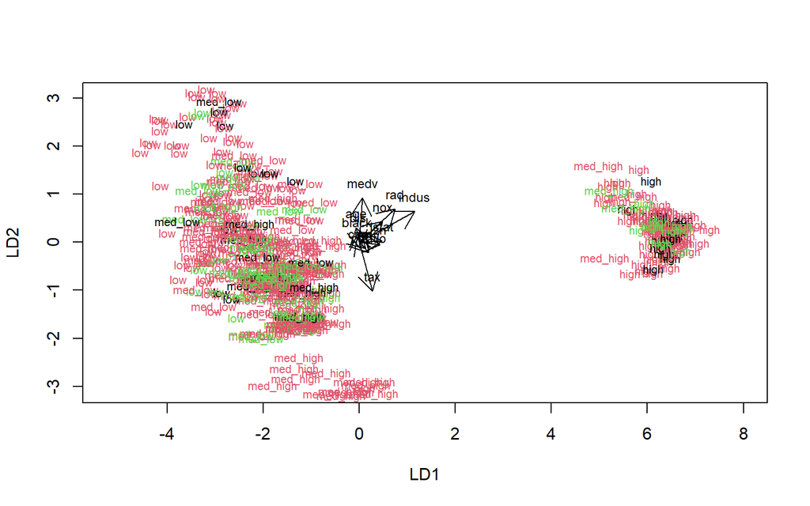

```r
# plotting the analysis

lda.arrows <- function(x, myscale = 1, arrow_heads = 0.2, color = "black", tex = 0.75, choices = c(1,2)){
  heads <- coef(x)
  graphics::arrows(x0 = 0, y0 = 0,
         x1 = myscale * heads[,choices[1]],
         y1 = myscale * heads[,choices[2]], col=color, length = arrow_heads)
  text(myscale * heads[,choices], labels = row.names(heads),
       cex = tex, col=color, pos=3)}

classes <- as.numeric(data_with_clusters$cluster)

plot(lda.fit, dimen = 2, col = classes)
lda.arrows(lda.bonus, myscale = 1)
```

Thats all folks.

# Dimensionality reduction techniques

First lets read and prepare the data. Data wrangling can also be found in the data folder:

```r
library(readr)
human <- read_csv("https://raw.githubusercontent.com/KimmoVehkalahti/Helsinki-Open-Data-Science/master/datasets/human2.csv", show_col_types = FALSE)
summary(human)
```

```
##    Country             Edu2.FM          Labo.FM          Life.Exp
##  Length:155         Min.   :0.1717   Min.   :0.1857   Min.   :49.00
##  Class :character   1st Qu.:0.7264   1st Qu.:0.5984   1st Qu.:66.30
##  Mode  :character   Median :0.9375   Median :0.7535   Median :74.20
##                     Mean   :0.8529   Mean   :0.7074   Mean   :71.65
##                     3rd Qu.:0.9968   3rd Qu.:0.8535   3rd Qu.:77.25
##                     Max.   :1.4967   Max.   :1.0380   Max.   :83.50
##     Edu.Exp           GNI            Mat.Mor         Ado.Birth
##  Min.   : 5.40   Min.   :   581   Min.   :   1.0   Min.   :  0.60
##  1st Qu.:11.25   1st Qu.:  4198   1st Qu.:  11.5   1st Qu.: 12.65
##  Median :13.50   Median : 12040   Median :  49.0   Median : 33.60
##  Mean   :13.18   Mean   : 17628   Mean   : 149.1   Mean   : 47.16
##  3rd Qu.:15.20   3rd Qu.: 24512   3rd Qu.: 190.0   3rd Qu.: 71.95
##  Max.   :20.20   Max.   :123124   Max.   :1100.0   Max.   :204.80
##     Parli.F
##  Min.   : 0.00
##  1st Qu.:12.40
##  Median :19.30
##  Mean   :20.91
##  3rd Qu.:27.95
##  Max.   :57.50
```

firsty, lets move the country names to row names and describe the results:

```r
# move the country names to rownames
library(tibble)
human_ <- column_to_rownames(human, "Country")


# Check the structure of the data frame after conversion
str(human_)
```

```
## 'data.frame':    155 obs. of  8 variables:
##  $ Edu2.FM  : num  1.007 0.997 0.983 0.989 0.969 ...
##  $ Labo.FM  : num  0.891 0.819 0.825 0.884 0.829 ...
##  $ Life.Exp : num  81.6 82.4 83 80.2 81.6 80.9 80.9 79.1 82 81.8 ...
##  $ Edu.Exp  : num  17.5 20.2 15.8 18.7 17.9 16.5 18.6 16.5 15.9 19.2 ...
##  $ GNI      : num  64992 42261 56431 44025 45435 ...
##  $ Mat.Mor  : num  4 6 6 5 6 7 9 28 11 8 ...
##  $ Ado.Birth: num  7.8 12.1 1.9 5.1 6.2 3.8 8.2 31 14.5 25.3 ...
##  $ Parli.F  : num  39.6 30.5 28.5 38 36.9 36.9 19.9 19.4 28.2 31.4 ...
```

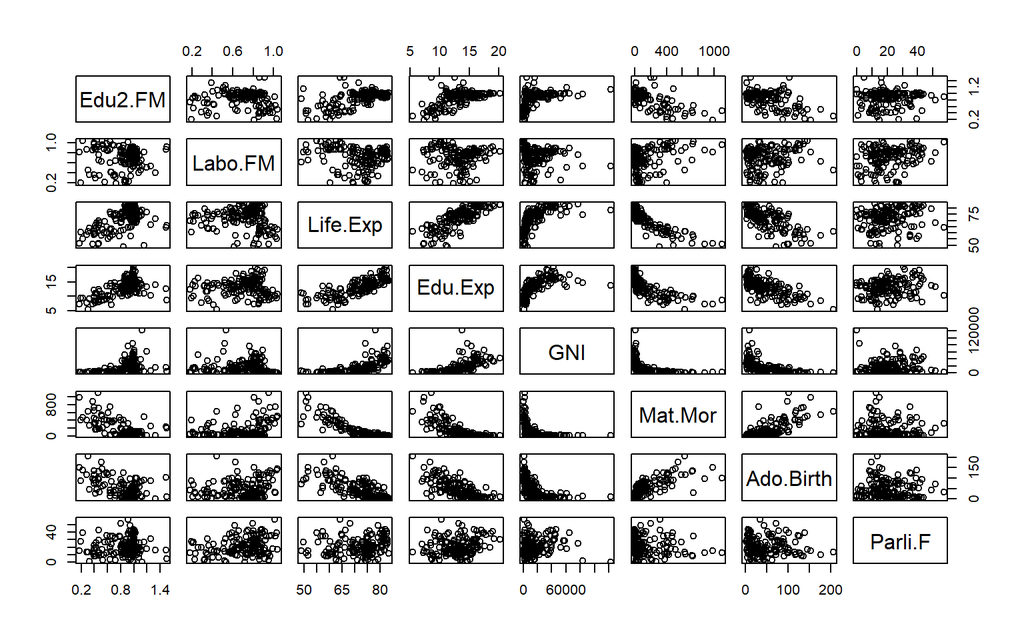

```r
# visualize the 'human_' variables
library(GGally)
pairs(human_)
```

```r
# Access corrplot
library(corrplot)

# compute the correlation matrix and visualize it with corrplot
cor_matrix<-cor(human_) %>% round(digits = 2)
cor_matrix
```

```
##           Edu2.FM Labo.FM Life.Exp Edu.Exp   GNI Mat.Mor Ado.Birth Parli.F
## Edu2.FM      1.00    0.01     0.58    0.59  0.43   -0.66     -0.53    0.08
## Labo.FM      0.01    1.00    -0.14    0.05 -0.02    0.24      0.12    0.25
## Life.Exp     0.58   -0.14     1.00    0.79  0.63   -0.86     -0.73    0.17
## Edu.Exp      0.59    0.05     0.79    1.00  0.62   -0.74     -0.70    0.21
## GNI          0.43   -0.02     0.63    0.62  1.00   -0.50     -0.56    0.09
## Mat.Mor     -0.66    0.24    -0.86   -0.74 -0.50    1.00      0.76   -0.09
## Ado.Birth   -0.53    0.12    -0.73   -0.70 -0.56    0.76      1.00   -0.07
## Parli.F      0.08    0.25     0.17    0.21  0.09   -0.09     -0.07    1.00
```

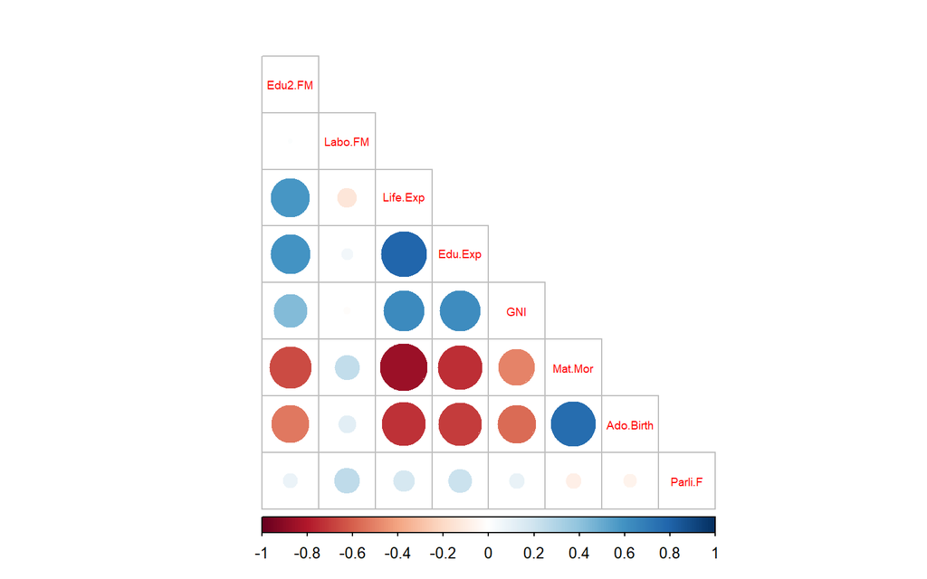

```r
corrplot(cor_matrix, method="circle", type="lower", cl.pos="b", tl.pos="d", tl.cex = 0.6)
```

It seems that there is strong positive correlation between life expectancy at birth (Life.exp) and expected years of schooling (Edu.exp) and Adolescent birth rate (Ado.Birth) and Maternal mortality ratio (Mat.Mor). There is also a strong negative correlation between life expectancy at birth (Life.exp) and Maternal mortality ratio (Mat.Mor) and expected years of schooling (Edu.exp) and maternal mortality ratio.

Next lets do a principal component analysis (PCA) on the data:

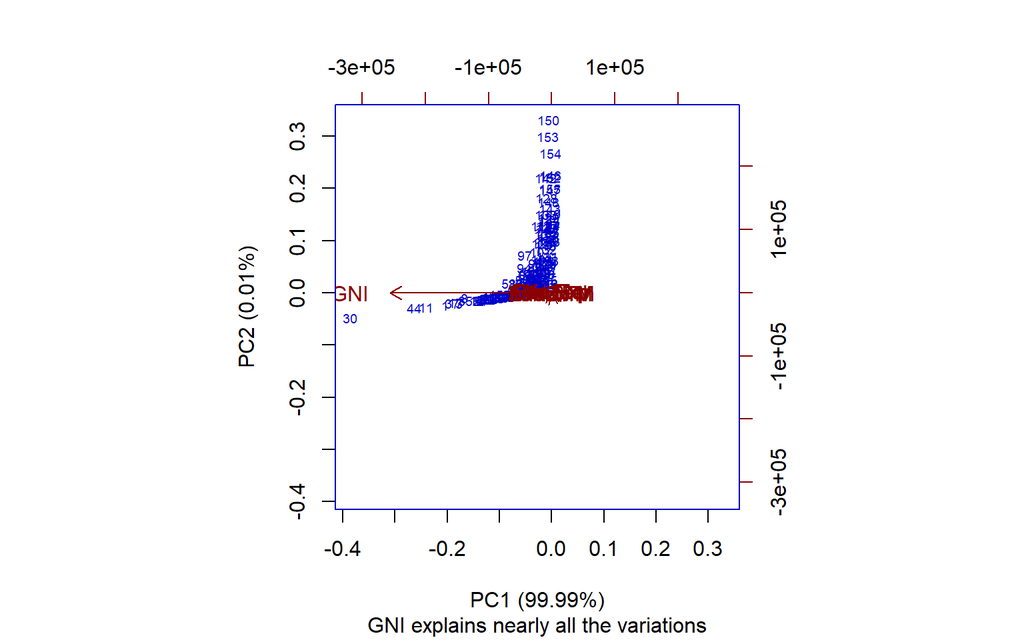

```r
pca <- prcomp(human_, center = F, scale. = F)
sum <- summary(pca)

# biplot
pca_names <- round(100*sum$importance[2,], digits = 2)
biplot(pca, choices = 1:2, cex = c(0.6, 1), col = c("blue3", "red4"),
       xlabs = c(1:nrow(human)), xlab = paste0("PC1 (", pca_names[1], "%)"),
       ylab = paste0("PC2 (", pca_names[2], "%)"), sub = "GNI explains nearly all the variations" )
```

The variable GNI or Gross National Income per capita seems to explain all the variations in the data with this model. This is very weird, so lets try another approach by standardizing the data:

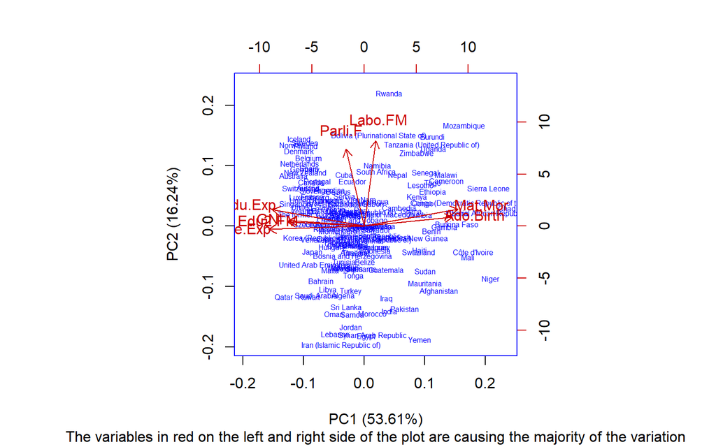

```r
pca <- prcomp(human_, center = T, scale. = T)
sum <- summary(pca)
pca_names <- round(100*sum$importance[2,], digits = 2)
biplot(pca, choices = 1:2, cex = c(0.5, 1), col = c("blue", "red3"),
       #xlabs = c(1:nrow(human)),
       xlab = paste0("PC1 (", pca_names[1], "%)"),
       ylab = paste0("PC2 (", pca_names[2], "%)"), sub = "The variables in red on the left and right side of the plot are causing the majority of the variation")
```

Now the PCA looks more realistic. Now this is due to the mathematic formula the PCA follows. Standardizing the data for PCA ensures that all variables have the same scale, preventing variables with larger magnitudes from dominating the analysis, as seen in the first PCA. PCA is sensitive to the relative magnitudes of variables. Non-standardized data, may lead to biased results, as variables with larger scales could disproportionately influence the principal components. Standardization allows PCA to focus on the underlying patterns in the data, promoting a more equitable representation of each variable in the analysis.

PC2, responsible for explaining 16% of the variation, is positively associated with female participation in society, encompassing the labor force and the percentage of females in parliament. A high PC2 value for a country suggests that females significantly influence society within that context.

Variables such as “labo.FM” (Labor Force Female/Male Ratio) and “Parl.E” (Percentage of Female Representatives in Parliament) play roles in illustrating these associations. In summary, the second PC sheds light on the impact of females on society through both their involvement in the workforce and political representation.

## The tea data explorations

First let’s load the tea data and observe it:

```r
tea <- read.csv("https://raw.githubusercontent.com/KimmoVehkalahti/Helsinki-Open-Data-Science/master/datasets/tea.csv", stringsAsFactors = TRUE)
str(tea)
```

```
## 'data.frame':    300 obs. of  36 variables:
##  $ breakfast       : Factor w/ 2 levels "breakfast","Not.breakfast": 1 1 2 2 1 2 1 2 1 1 ...
##  $ tea.time        : Factor w/ 2 levels "Not.tea time",..: 1 1 2 1 1 1 2 2 2 1 ...
##  $ evening         : Factor w/ 2 levels "evening","Not.evening": 2 2 1 2 1 2 2 1 2 1 ...
##  $ lunch           : Factor w/ 2 levels "lunch","Not.lunch": 2 2 2 2 2 2 2 2 2 2 ...
##  $ dinner          : Factor w/ 2 levels "dinner","Not.dinner": 2 2 1 1 2 1 2 2 2 2 ...
##  $ always          : Factor w/ 2 levels "always","Not.always": 2 2 2 2 1 2 2 2 2 2 ...
##  $ home            : Factor w/ 2 levels "home","Not.home": 1 1 1 1 1 1 1 1 1 1 ...
##  $ work            : Factor w/ 2 levels "Not.work","work": 1 1 2 1 1 1 1 1 1 1 ...
##  $ tearoom         : Factor w/ 2 levels "Not.tearoom",..: 1 1 1 1 1 1 1 1 1 2 ...
##  $ friends         : Factor w/ 2 levels "friends","Not.friends": 2 2 1 2 2 2 1 2 2 2 ...
##  $ resto           : Factor w/ 2 levels "Not.resto","resto": 1 1 2 1 1 1 1 1 1 1 ...
##  $ pub             : Factor w/ 2 levels "Not.pub","pub": 1 1 1 1 1 1 1 1 1 1 ...
##  $ Tea             : Factor w/ 3 levels "black","Earl Grey",..: 1 1 2 2 2 2 2 1 2 1 ...
##  $ How             : Factor w/ 4 levels "alone","lemon",..: 1 3 1 1 1 1 1 3 3 1 ...
```

[output cut: 22 more lines]

```r
dim(tea)
```

```
## [1] 300  36
```

```r
view(tea)
```

Then lets make this more easier to handle:

```r
# needed packages

library(dplyr)
library(tidyr)
library(ggplot2)

# visualising only certain columns

keep_columns <- c("Tea", "How", "how", "sugar", "where", "lunch")
tea_time <- dplyr::select(tea, keep_columns)
dim(tea_time)
```

```
## [1] 300   6
```

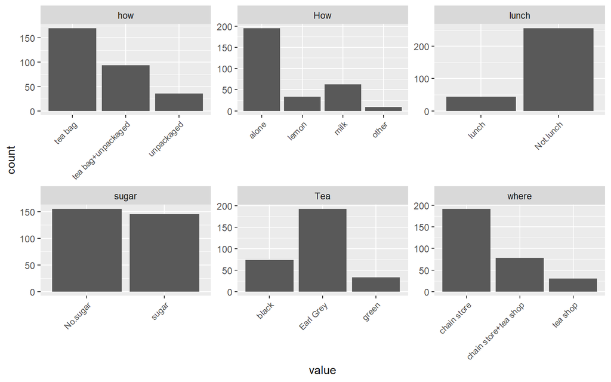

```r
pivot_longer(tea_time, cols = everything()) %>%
  ggplot(aes(value)) + facet_wrap("name", scales = "free") + geom_bar() + theme(axis.text.x = element_text(angle = 45, hjust = 1, size = 8))
```

Now let’s do multiple correspondence analysis (MCA) of the data:

```r
library(FactoMineR)
mca <- MCA(tea_time, graph = FALSE)
summary(mca)
```

```
##
## Call:
## MCA(X = tea_time, graph = FALSE)
##
##
## Eigenvalues
##                        Dim.1   Dim.2   Dim.3   Dim.4   Dim.5   Dim.6   Dim.7
## Variance               0.279   0.261   0.219   0.189   0.177   0.156   0.144
## % of var.             15.238  14.232  11.964  10.333   9.667   8.519   7.841
## Cumulative % of var.  15.238  29.471  41.435  51.768  61.434  69.953  77.794
##                        Dim.8   Dim.9  Dim.10  Dim.11
## Variance               0.141   0.117   0.087   0.062
## % of var.              7.705   6.392   4.724   3.385
## Cumulative % of var.  85.500  91.891  96.615 100.000
##
## Individuals (the 10 first)
##                       Dim.1    ctr   cos2    Dim.2    ctr   cos2    Dim.3
## 1                  | -0.298  0.106  0.086 | -0.328  0.137  0.105 | -0.327
## 2                  | -0.237  0.067  0.036 | -0.136  0.024  0.012 | -0.695
## 3                  | -0.369  0.162  0.231 | -0.300  0.115  0.153 | -0.202
## 4                  | -0.530  0.335  0.460 | -0.318  0.129  0.166 |  0.211
## 5                  | -0.369  0.162  0.231 | -0.300  0.115  0.153 | -0.202
## 6                  | -0.369  0.162  0.231 | -0.300  0.115  0.153 | -0.202
## 7                  | -0.369  0.162  0.231 | -0.300  0.115  0.153 | -0.202
## 8                  | -0.237  0.067  0.036 | -0.136  0.024  0.012 | -0.695
## 9                  |  0.143  0.024  0.012 |  0.871  0.969  0.435 | -0.067
## 10                 |  0.476  0.271  0.140 |  0.687  0.604  0.291 | -0.650
##                       ctr   cos2
## 1                   0.163  0.104 |
## 2                   0.735  0.314 |
## 3                   0.062  0.069 |
## 4                   0.068  0.073 |
## 5                   0.062  0.069 |
## 6                   0.062  0.069 |
## 7                   0.062  0.069 |
## 8                   0.735  0.314 |
## 9                   0.007  0.003 |
## 10                  0.643  0.261 |
##
## Categories (the 10 first)
```

[output cut: 16 more lines]

```
## lemon                3.226 |   1.329  14.771   0.218   8.081 |
## milk                 2.422 |   0.013   0.003   0.000   0.116 |
## other                5.534 |  -2.524  14.526   0.197  -7.676 |
## tea bag             -6.941 |  -0.065   0.183   0.006  -1.287 |
## tea bag+unpackaged  11.956 |   0.019   0.009   0.000   0.226 |
## unpackaged          -6.482 |   0.257   0.602   0.009   1.640 |
##
## Categorical variables (eta2)
##                      Dim.1 Dim.2 Dim.3
## Tea                | 0.126 0.108 0.410 |
## How                | 0.076 0.190 0.394 |
## how                | 0.708 0.522 0.010 |
## sugar              | 0.065 0.001 0.336 |
## where              | 0.702 0.681 0.055 |
## lunch              | 0.000 0.064 0.111 |
```

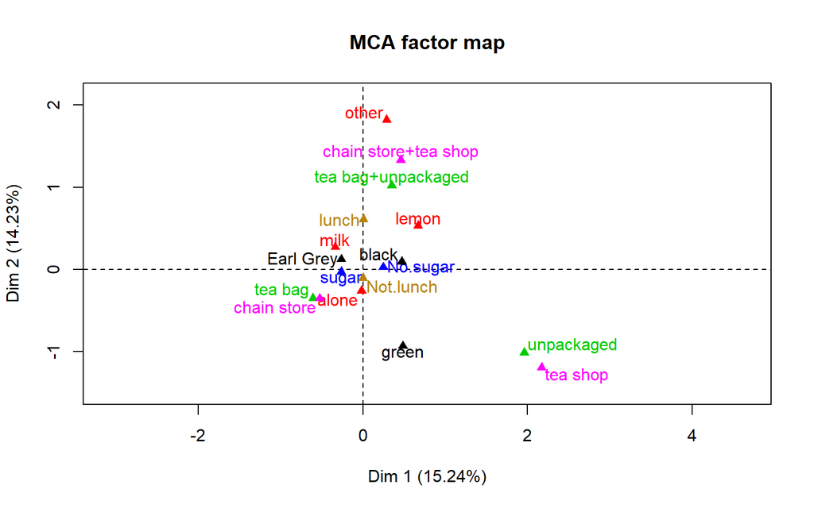

```r
plot(mca,invisible=c("ind"), habillage = "quali", graph.type = "classic")
```

The MCA explains 6 variables correlation to tea drinking. The whole data contains 300 observations. This 2 factorial model can explain combined almost 30 % of the data (14.23 % and 15.24 %). This is however not very much. The distance between two variables in the factor map describes the relationship between the variables. Let’s play with some other plotting options:

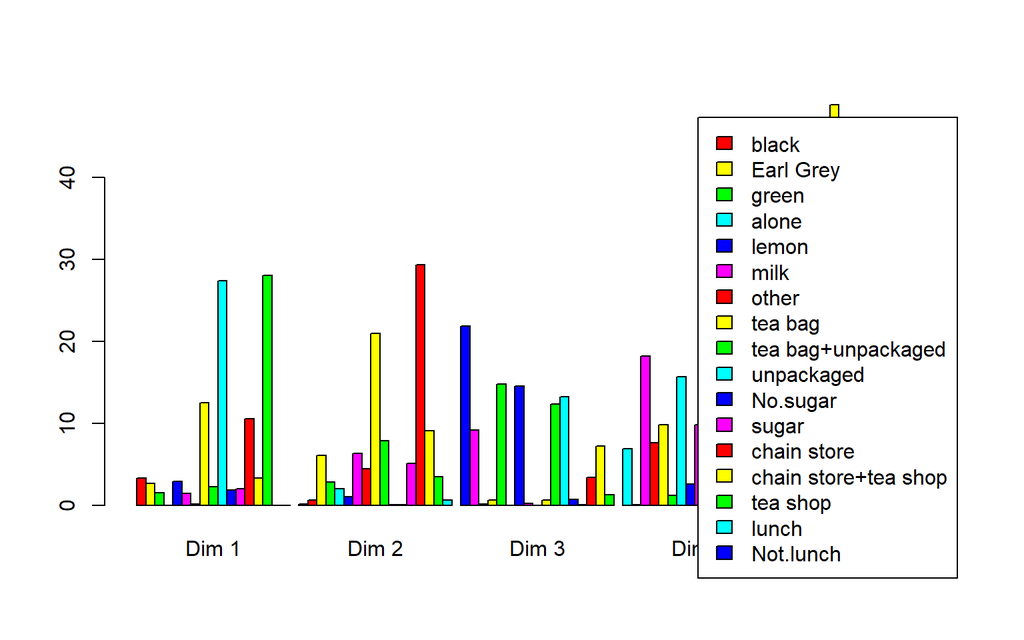

```r
barplot(mca$var$contrib, beside = T, col = rainbow(6),
        legend.text = rownames(mca$var$contrib))
```

```r
library(factoextra)
```

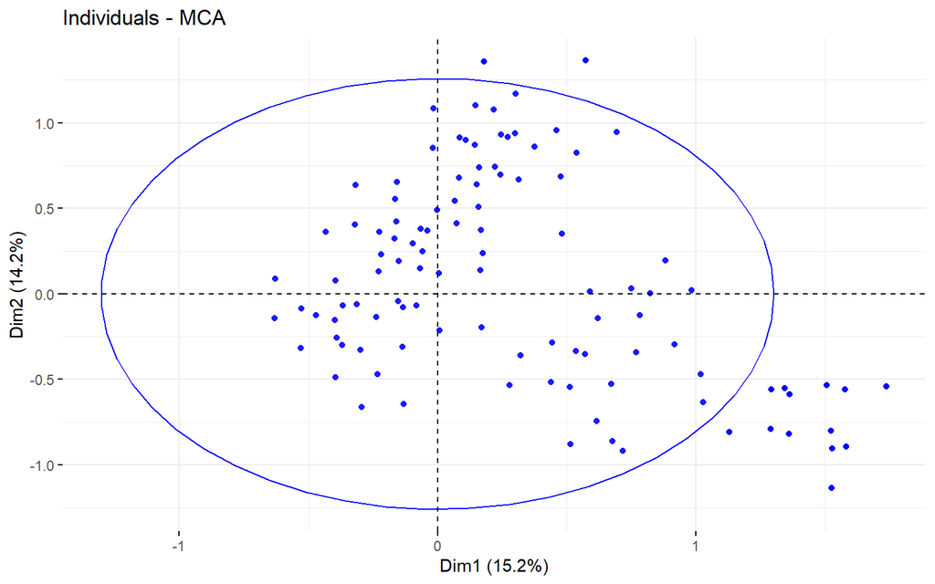

```r
fviz_mca_ind(mca, geom.ind = "point", col.ind = "blue",
             palette = c("red", "green", "blue"), addEllipses = TRUE)
```

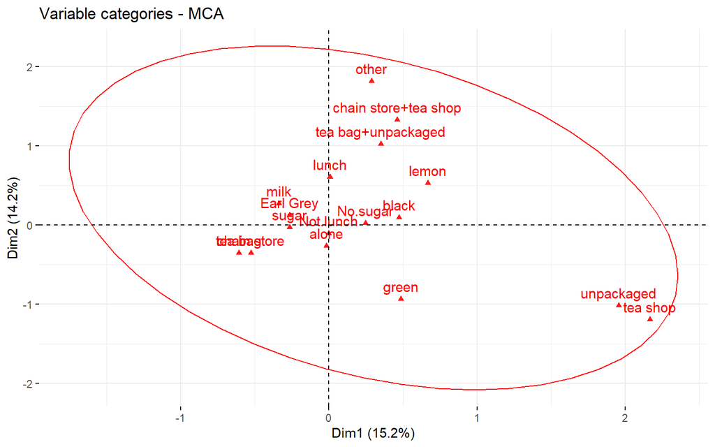

```r
fviz_mca_var(mca, geom.ind = "point", col.ind = "blue",
             palette = c("red", "green", "blue"), addEllipses = TRUE)
```

That was fun. Let’s continue next week.

# Analysis of longitudinal data

## meet and repeat: PART I

Lets first read the RATS data in to the environment and observe it:

```r
Rats <- read.csv("data//Rats_longitudinal.csv")
RATS <- read.table("https://raw.githubusercontent.com/KimmoVehkalahti/MABS/master/Examples/data/rats.txt", header = TRUE, sep = '\t')
glimpse(Rats)
```

```
## Rows: 176
## Columns: 6
## $ X     <int> 1, 2, 3, 4, 5, 6, 7, 8, 9, 10, 11, 12, 13, 14, 15, 16, 17, 18, 1…
## $ ID    <int> 1, 2, 3, 4, 5, 6, 7, 8, 9, 10, 11, 12, 13, 14, 15, 16, 1, 2, 3, …
## $ Group <int> 1, 1, 1, 1, 1, 1, 1, 1, 2, 2, 2, 2, 3, 3, 3, 3, 1, 1, 1, 1, 1, 1…
## $ WD    <chr> "WD1", "WD1", "WD1", "WD1", "WD1", "WD1", "WD1", "WD1", "WD1", "…
## $ rats  <int> 240, 225, 245, 260, 255, 260, 275, 245, 410, 405, 445, 555, 470,…
## $ Time  <int> 1, 1, 1, 1, 1, 1, 1, 1, 1, 1, 1, 1, 1, 1, 1, 1, 15, 15, 15, 15, …
```

Lets change the factorial variables to be just that:

```r
Rats$ID <- factor(Rats$ID)
Rats$Group <- factor(Rats$Group)

# lets observe the data
glimpse(Rats)
```

```
## Rows: 176
## Columns: 6
## $ X     <int> 1, 2, 3, 4, 5, 6, 7, 8, 9, 10, 11, 12, 13, 14, 15, 16, 17, 18, 1…
## $ ID    <fct> 1, 2, 3, 4, 5, 6, 7, 8, 9, 10, 11, 12, 13, 14, 15, 16, 1, 2, 3, …
## $ Group <fct> 1, 1, 1, 1, 1, 1, 1, 1, 2, 2, 2, 2, 3, 3, 3, 3, 1, 1, 1, 1, 1, 1…
## $ WD    <chr> "WD1", "WD1", "WD1", "WD1", "WD1", "WD1", "WD1", "WD1", "WD1", "…
## $ rats  <int> 240, 225, 245, 260, 255, 260, 275, 245, 410, 405, 445, 555, 470,…
## $ Time  <int> 1, 1, 1, 1, 1, 1, 1, 1, 1, 1, 1, 1, 1, 1, 1, 1, 15, 15, 15, 15, …
```

```r
summary(Rats)
```

```
##        X                ID      Group       WD                 rats
##  Min.   :  1.00   1      : 11   1:88   Length:176         Min.   :225.0
##  1st Qu.: 44.75   2      : 11   2:44   Class :character   1st Qu.:267.0
##  Median : 88.50   3      : 11   3:44   Mode  :character   Median :344.5
##  Mean   : 88.50   4      : 11                             Mean   :384.5
##  3rd Qu.:132.25   5      : 11                             3rd Qu.:511.2
##  Max.   :176.00   6      : 11                             Max.   :628.0
##                   (Other):110
##       Time
##  Min.   : 1.00
##  1st Qu.:15.00
##  Median :36.00
##  Mean   :33.55
##  3rd Qu.:50.00
##  Max.   :64.00
##
```

```r
colnames(Rats)
```

```
## [1] "X"     "ID"    "Group" "WD"    "rats"  "Time"
```

Now lets experiment with the data with some plots

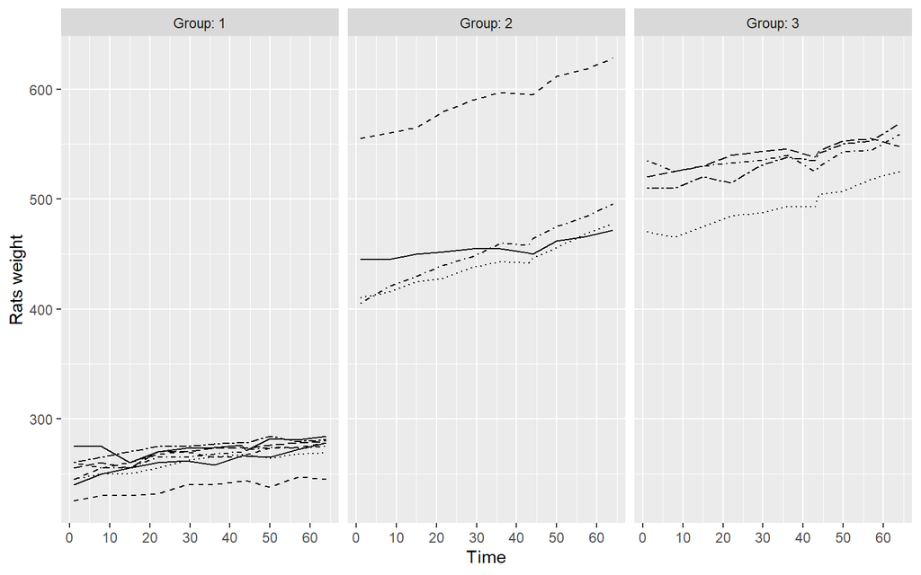

```r
library(ggplot2)

ggplot(Rats, aes(x = Time, y = rats, linetype = ID)) +
  geom_line() +
  scale_linetype_manual(values = rep(1:10, times=4)) +
  facet_grid(. ~ Group, labeller = label_both) +
  theme(legend.position = "none") +
  scale_x_continuous(name = "Time", breaks = seq(0,60,10)) +
  scale_y_continuous(name = "Rats weight")
```

This plot illustrates the weight of the rats by treatment groups. Immediately, we can see that Group 1 is lighter than group 2 or 3. Also, there is a quite noticeable outlier in group 2.

Lets standardize the data so that we can see the absolute differences better.

```r
library(dplyr); library(tidyr); library(ggplot2)

# Standardize the variable rats
Rats <- Rats %>%
  group_by(Time) %>%
  mutate(stdrats = (rats - mean(rats))/sd(rats) ) %>%
  ungroup()

# Glimpse the data
glimpse(Rats)
```

```
## Rows: 176
## Columns: 7
## $ X       <int> 1, 2, 3, 4, 5, 6, 7, 8, 9, 10, 11, 12, 13, 14, 15, 16, 17, 18,…
## $ ID      <fct> 1, 2, 3, 4, 5, 6, 7, 8, 9, 10, 11, 12, 13, 14, 15, 16, 1, 2, 3…
## $ Group   <fct> 1, 1, 1, 1, 1, 1, 1, 1, 2, 2, 2, 2, 3, 3, 3, 3, 1, 1, 1, 1, 1,…
## $ WD      <chr> "WD1", "WD1", "WD1", "WD1", "WD1", "WD1", "WD1", "WD1", "WD1",…
## $ rats    <int> 240, 225, 245, 260, 255, 260, 275, 245, 410, 405, 445, 555, 47…
## $ Time    <int> 1, 1, 1, 1, 1, 1, 1, 1, 1, 1, 1, 1, 1, 1, 1, 1, 15, 15, 15, 15…
## $ stdrats <dbl> -1.0011429, -1.1203857, -0.9613953, -0.8421525, -0.8819001, -0…
```

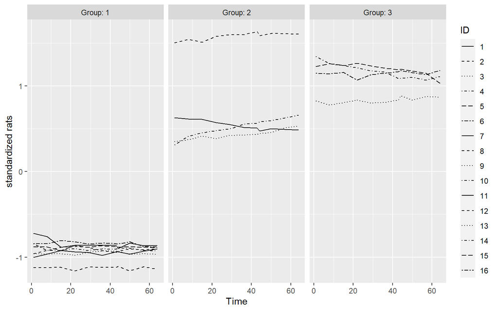

```r
# Plot again with the standardized rats
library(ggplot2)
ggplot(Rats, aes(x = Time, y = stdrats, linetype = ID)) +
  geom_line() +
  scale_linetype_manual(values = rep(1:10, times=4)) +
  facet_grid(. ~ Group, labeller = label_both) +
  scale_y_continuous(name = "standardized rats")
```

The growing trend of the weights are now disappeared. Lets check the stardard error of the mean in rats weight and provide a graphical overview:

```r
# lets create summary data
n <- Rats$Time %>% unique() %>% length()
Ratss <- Rats %>%
  group_by(Time, Group) %>%
  summarise( mean = mean(rats), se = sd(rats)/sqrt(n) ) %>%
  ungroup()
glimpse(Ratss)
```

```
## Rows: 33
## Columns: 4
## $ Time  <int> 1, 1, 1, 8, 8, 8, 15, 15, 15, 22, 22, 22, 29, 29, 29, 36, 36, 36…
## $ Group <fct> 1, 2, 3, 1, 2, 3, 1, 2, 3, 1, 2, 3, 1, 2, 3, 1, 2, 3, 1, 2, 3, 1…
## $ mean  <dbl> 250.625, 453.750, 508.750, 255.000, 460.000, 506.250, 254.375, 4…
## $ se    <dbl> 4.589478, 21.047385, 8.382431, 3.947710, 20.486507, 8.561276, 3.…
```

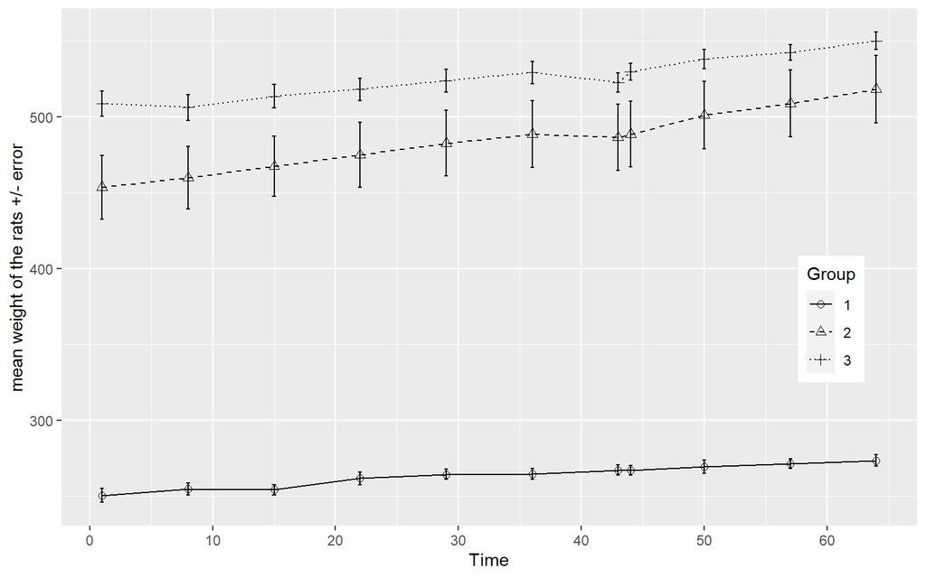

```r
ggplot(Ratss, aes(x = Time, y = mean, linetype = Group, shape = Group)) +
  geom_line() +
  scale_linetype_manual(values = c(1,2,3)) +
  geom_point(size=2) +
  scale_shape_manual(values = c(1,2,3)) +
  geom_errorbar(aes(ymin=mean-se, ymax=mean+se, linetype="1"), width=0.3) +
  theme(legend.position = c(0.9,0.4)) +
  scale_x_continuous(name = "Time", breaks = seq(0, 60, 10)) +
  scale_y_continuous(name = "mean weight of the rats +/- error")
```

We can with this see clearly that the groups 2 and 3 have significantly higher weight. However as we remenber, we had a significant abnormal weight observations in the group 2. Lets find the outlier:

```r
Ratssum <- Rats %>%
  filter(Time > 0) %>%
  group_by(Group, ID) %>%
  summarise( mean=mean(rats) ) %>%
  ungroup()
glimpse(Ratssum)
```

```
## Rows: 16
## Columns: 3
## $ Group <fct> 1, 1, 1, 1, 1, 1, 1, 1, 2, 2, 2, 2, 3, 3, 3, 3
## $ ID    <fct> 1, 2, 3, 4, 5, 6, 7, 8, 9, 10, 11, 12, 13, 14, 15, 16
## $ mean  <dbl> 261.0909, 237.6364, 260.1818, 266.5455, 269.4545, 274.7273, 274.…
```

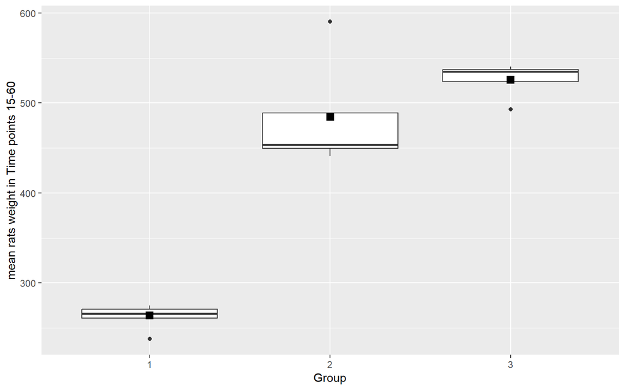

```r
# Draw a boxplot of the mean versus Group
library(ggplot2)
ggplot(Ratssum, aes(x = Group, y = mean)) +
  geom_boxplot() +
  stat_summary(fun = "mean", geom = "point", shape=15, size=3, fill = "pink") +
  scale_y_continuous(name = "mean rats weight in Time points 15-60")
```

One of the means in group 2 is much higher compared to others so it will be brutally dropped as an outlier.

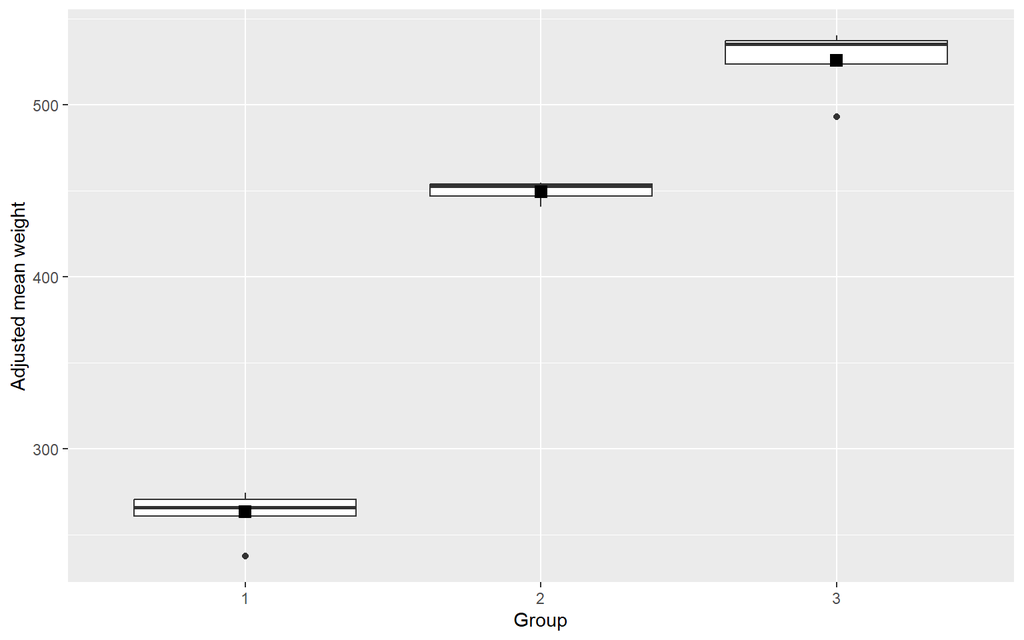

```r
Ratssum1 <- Ratssum %>% filter(mean < 550)
ggplot(Ratssum1, aes(x = Group, y = mean)) +
  geom_boxplot() +
  stat_summary(fun.y = "mean", geom = "point", shape=15, size=3, fill = "pink") +
  scale_y_continuous(name = "Adjusted mean weight")
```

Now this is better. Lets then check the significance between the groups with linear regression analysis:

```r
library(dplyr)
library(tidyr)

# removing the outlier

RATS1 <- RATS[c(-12),]

# Add the baseline from the original data as a new variable to the summary data
Ratssum1 <- Ratssum1 %>% mutate(baseline = RATS1$WD1)
Ratssum <- Ratssum %>% mutate(baseline = RATS$WD1)

# Fit the linear model with the mean as the response
fit <- lm(mean ~ baseline + Group, data = Ratssum1)
fit1 <- lm(mean ~ baseline + Group, data = Ratssum)


# Compute the analysis of variance table for the fitted model with anova()
anova(fit)
```

```
## Analysis of Variance Table
##
## Response: mean
##           Df Sum Sq Mean Sq   F value    Pr(>F)
## baseline   1 207029  207029 3272.6190 5.751e-15 ***
## Group      2   1226     613    9.6878  0.003748 **
## Residuals 11    696      63
## ---
## Signif. codes:  0 '***' 0.001 '**' 0.01 '*' 0.05 '.' 0.1 ' ' 1
```

```r
anova(fit1)
```

```
## Analysis of Variance Table
##
## Response: mean
##           Df Sum Sq Mean Sq   F value    Pr(>F)
## baseline   1 252125  252125 2237.0655 5.217e-15 ***
## Group      2    726     363    3.2219   0.07586 .
## Residuals 12   1352     113
## ---
## Signif. codes:  0 '***' 0.001 '**' 0.01 '*' 0.05 '.' 0.1 ' ' 1
```

We can see from the anova results that there is significant differences between the means of the different groups (p = 0.0037). If the outlier would not have been removed, the significance would have been non significant at 0.05 alfa value. Therefore, its important to consider the outliers in the data prior to processing.

## meet and repeat: PART II

Lets read us the new pbrs data to be evaluated. This data represents 40 male subjects that were receiving different treatment for eight weeks during which they were rated on brief psychiatric rating scale (BPRS). It is used to evaluate the level of schizophrenia:

```r
Bprs <- read.csv("data//Bprsl_longitudinal.csv")
summary(Bprs)
```

```
##        X            treatment      subject         weeks
##  Min.   :  1.00   Min.   :1.0   Min.   : 1.00   Length:360
##  1st Qu.: 90.75   1st Qu.:1.0   1st Qu.: 5.75   Class :character
##  Median :180.50   Median :1.5   Median :10.50   Mode  :character
##  Mean   :180.50   Mean   :1.5   Mean   :10.50
##  3rd Qu.:270.25   3rd Qu.:2.0   3rd Qu.:15.25
##  Max.   :360.00   Max.   :2.0   Max.   :20.00
##       bprs            week
##  Min.   :18.00   Min.   :0
##  1st Qu.:27.00   1st Qu.:2
##  Median :35.00   Median :4
##  Mean   :37.66   Mean   :4
##  3rd Qu.:43.00   3rd Qu.:6
##  Max.   :95.00   Max.   :8
```

```r
colnames(Bprs)
```

```
## [1] "X"         "treatment" "subject"   "weeks"     "bprs"      "week"
```

```r
str(Bprs)
```

```
## 'data.frame':    360 obs. of  6 variables:
##  $ X        : int  1 2 3 4 5 6 7 8 9 10 ...
##  $ treatment: int  1 1 1 1 1 1 1 1 1 1 ...
##  $ subject  : int  1 2 3 4 5 6 7 8 9 10 ...
##  $ weeks    : chr  "week0" "week0" "week0" "week0" ...
##  $ bprs     : int  42 58 54 55 72 48 71 30 41 57 ...
##  $ week     : int  0 0 0 0 0 0 0 0 0 0 ...
```

Lets change the factorial variables to be just that:

```r
Bprs$treatment <- factor(Bprs$treatment)
Bprs$subject <- factor(Bprs$subject)

str(Bprs)
```

```
## 'data.frame':    360 obs. of  6 variables:
##  $ X        : int  1 2 3 4 5 6 7 8 9 10 ...
##  $ treatment: Factor w/ 2 levels "1","2": 1 1 1 1 1 1 1 1 1 1 ...
##  $ subject  : Factor w/ 20 levels "1","2","3","4",..: 1 2 3 4 5 6 7 8 9 10 ...
##  $ weeks    : chr  "week0" "week0" "week0" "week0" ...
##  $ bprs     : int  42 58 54 55 72 48 71 30 41 57 ...
##  $ week     : int  0 0 0 0 0 0 0 0 0 0 ...
```

The data here that we are about to process needs to be in a longitudinal form. This is already done in the data wrangling part which you can find in the data folder file Meet_and_repeat.R in this repository. Therefore, we can jump right in to checking how the treatment has affected the bprs responses of the patients:

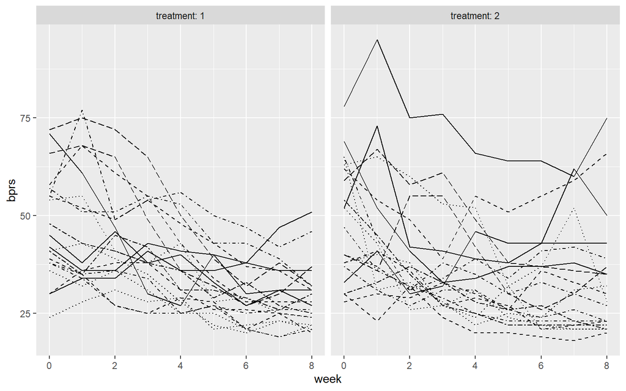

```r
# needed libraries
library(dplyr)
library(tidyr)

# Plot the Bprs data
library(ggplot2)
ggplot(Bprs, aes(x = week, y = bprs, linetype = subject)) +
  geom_line() +
  scale_linetype_manual(values = rep(1:10, times=4)) +
  facet_grid(. ~ treatment, labeller = label_both) +
  theme(legend.position = "none") +
  scale_y_continuous(limits = c(min(Bprs$bprs), max(Bprs$bprs)))
```

```r
linear <- lm(bprs ~ week + treatment, data = Bprs)
summary(linear)
```

```
##
## Call:
## lm(formula = bprs ~ week + treatment, data = Bprs)
##
## Residuals:
##     Min      1Q  Median      3Q     Max
## -22.454  -8.965  -3.196   7.002  50.244
##
## Coefficients:
##             Estimate Std. Error t value Pr(>|t|)
## (Intercept)  46.4539     1.3670  33.982   <2e-16 ***
## week         -2.2704     0.2524  -8.995   <2e-16 ***
## treatment2    0.5722     1.3034   0.439    0.661
## ---
## Signif. codes:  0 '***' 0.001 '**' 0.01 '*' 0.05 '.' 0.1 ' ' 1
##
## Residual standard error: 12.37 on 357 degrees of freedom
## Multiple R-squared:  0.1851, Adjusted R-squared:  0.1806
## F-statistic: 40.55 on 2 and 357 DF,  p-value: < 2.2e-16
```

This model assumes that the measures made are independent. As this is related data, so continous answers from the same participant over the weeks, we have to do the random intercept model:

```r
library(lme4)
random <- lmer(bprs ~ week + treatment + (1 | subject), data = Bprs, REML = FALSE)
summary(random)
```

```
## Linear mixed model fit by maximum likelihood  ['lmerMod']
## Formula: bprs ~ week + treatment + (1 | subject)
##    Data: Bprs
##
##      AIC      BIC   logLik deviance df.resid
##   2748.7   2768.1  -1369.4   2738.7      355
##
## Scaled residuals:
##     Min      1Q  Median      3Q     Max
## -3.0481 -0.6749 -0.1361  0.4813  3.4855
##
## Random effects:
##  Groups   Name        Variance Std.Dev.
##  subject  (Intercept)  47.41    6.885
##  Residual             104.21   10.208
## Number of obs: 360, groups:  subject, 20
##
## Fixed effects:
##             Estimate Std. Error t value
## (Intercept)  46.4539     1.9090  24.334
## week         -2.2704     0.2084 -10.896
## treatment2    0.5722     1.0761   0.532
##
## Correlation of Fixed Effects:
##            (Intr) week
## week       -0.437
## treatment2 -0.282  0.000
```

The updated model produces more appropriate results; for instance, the standard error for the week is now reduced. However, the model does not exhibit an optimal fit. To achieve an even better fit for this type of real-life data, both random intercept and random slope components are employed:

```r
random2 <- lmer(bprs ~ week + treatment + (week | subject), data = Bprs, REML = FALSE)
summary(random2)
```

```
## Linear mixed model fit by maximum likelihood  ['lmerMod']
## Formula: bprs ~ week + treatment + (week | subject)
##    Data: Bprs
##
##      AIC      BIC   logLik deviance df.resid
##   2745.4   2772.6  -1365.7   2731.4      353
##
## Scaled residuals:
##     Min      1Q  Median      3Q     Max
## -2.8919 -0.6194 -0.0691  0.5531  3.7976
##
## Random effects:
##  Groups   Name        Variance Std.Dev. Corr
##  subject  (Intercept) 64.8222  8.0512
##           week         0.9609  0.9802   -0.51
##  Residual             97.4305  9.8707
## Number of obs: 360, groups:  subject, 20
##
## Fixed effects:
##             Estimate Std. Error t value
## (Intercept)  46.4539     2.1052  22.066
## week         -2.2704     0.2977  -7.626
## treatment2    0.5722     1.0405   0.550
##
## Correlation of Fixed Effects:
##            (Intr) week
## week       -0.582
## treatment2 -0.247  0.000
```

```r
# Anova of both models

anova(random, random2)
```

```
## Data: Bprs
## Models:
## random: bprs ~ week + treatment + (1 | subject)
## random2: bprs ~ week + treatment + (week | subject)
##         npar    AIC    BIC  logLik deviance  Chisq Df Pr(>Chisq)
## random     5 2748.7 2768.1 -1369.4   2738.7
## random2    7 2745.4 2772.6 -1365.7   2731.4 7.2721  2    0.02636 *
## ---
## Signif. codes:  0 '***' 0.001 '**' 0.01 '*' 0.05 '.' 0.1 ' ' 1
```

The p-value for the second model is lower, which indicates that its better at describing this model. We can still try one more approach:

```r
random3 <- lmer(bprs ~ week * treatment + (week | treatment), data = Bprs, REML = FALSE)
```

```
## boundary (singular) fit: see help('isSingular')
```

```r
summary(random3)
```

```
## Linear mixed model fit by maximum likelihood  ['lmerMod']
## Formula: bprs ~ week * treatment + (week | treatment)
##    Data: Bprs
##
##      AIC      BIC   logLik deviance df.resid
##   2843.3   2874.4  -1413.7   2827.3      352
##
## Scaled residuals:
##     Min      1Q  Median      3Q     Max
## -1.9453 -0.7547 -0.2281  0.5304  4.1794
##
## Random effects:
##  Groups    Name        Variance  Std.Dev.  Corr
##  treatment (Intercept) 2.571e-07 5.071e-04
##            week        6.318e-09 7.948e-05 -1.00
##  Residual              1.508e+02 1.228e+01
## Number of obs: 360, groups:  treatment, 2
##
## Fixed effects:
##                 Estimate Std. Error t value
## (Intercept)      47.8856     1.6876  28.376
## week             -2.6283     0.3545  -7.415
## treatment2       -2.2911     2.3866  -0.960
## week:treatment2   0.7158     0.5013   1.428
##
## Correlation of Fixed Effects:
##             (Intr) week   trtmn2
## week        -0.840
## treatment2  -0.707  0.594
## wek:trtmnt2  0.594 -0.707 -0.840
## optimizer (nloptwrap) convergence code: 0 (OK)
## boundary (singular) fit: see help('isSingular')
```

```r
anova(random2, random3)
```

```
## Data: Bprs
## Models:
## random2: bprs ~ week + treatment + (week | subject)
## random3: bprs ~ week * treatment + (week | treatment)
##         npar    AIC    BIC  logLik deviance Chisq Df Pr(>Chisq)
## random2    7 2745.4 2772.6 -1365.7   2731.4
## random3    8 2843.3 2874.4 -1413.7   2827.3     0  1          1
```

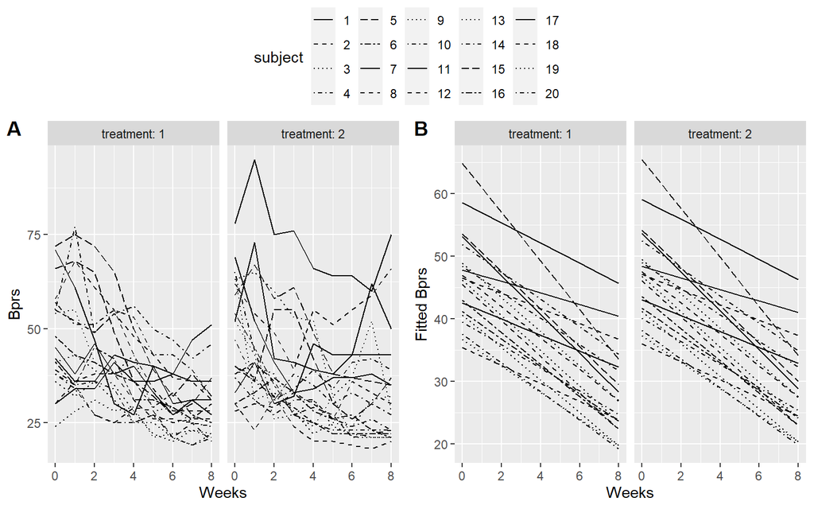

```r
p1 <- ggplot(Bprs, aes(x = week, y = bprs, linetype = subject)) +
  geom_line() +
  scale_x_continuous(name = "Weeks") +
  scale_y_continuous(name = "Bprs") +
  theme(legend.position = "none") +
  scale_linetype_manual(values = rep(1:10, times=4)) +
  facet_grid(. ~ treatment, labeller = label_both)

Fitted <- fitted(random2)
Bprs <- Bprs %>% mutate(fitted = Fitted)

p2 <- ggplot(Bprs, aes(x = week, y = Fitted, linetype = subject)) +
  geom_line() +
  scale_x_continuous(name = "Weeks") +
  scale_y_continuous(name = "Fitted Bprs") +
  theme(legend.position = "none") +
  scale_linetype_manual(values = rep(1:10, times=4)) +
  facet_grid(. ~ treatment, labeller = label_both)

ggpubr::ggarrange(
  plotlist = list(p1, p2), labels = "AUTO",
  common.legend = T)
```

This is the end of course. Cheers!

(more chapters to be added as we proceed with the course!)